# TextAnalytics

Lalit Jain

## Core objectives

1. Simplicity
2. Power
3. Best practice
   - workflow
   - transparency and reproducability
4. Performance
5. Inter-operability with other tools

## Basic Principles

1. Corpus texts are text repositories.
   - Should not have their texts modified as part of preparation or analysis
   - Subsetting or redefining documents is allowable
2. A corpus should be capable of holding additional objects that will be associated with the corpus, such as dictionaries, stopword, and phrase lists, that will propagate downstream.
3. Downstream objects should record the settings used to produce them.
   - includes: tokenized texts (`tokenizedTexts`), document-feature matrixes (`dfm`)
   - settings examples are: `tolower`, `stem`, `removeTwitter` etc.
   - also include any objects used in feature selection, such as dictionaries or stopword lists

## Basic Principles (cont.)

4. A document-feature matrix is a sparse matrix that is always *documents* (or document groups) in rows by *features* in columns.
5. Encoding of texts should be done in the corpus, and recorded as meta-data in the corpus
   - This encoding should be `UTF-8` by default (problem for Windows machines)
   - Basic text operations will use the `stringi` package, based on the ICU libraries for Unicode compliance

## Text analysis workflow: Corpora, documents, and features

1. Creating the corpus
   - reading files, probably using `textfile()`
   - creating a corpus using `corpus()`
   - converting encodings
   - adding document variables (`docvars`) and metadata (`metadoc` and `metacorpus`).
2. Defining and delimiting documents
   - defining what are “texts”, for instance using `changeunits` or grouping

## Text analysis workflow: Corpora, documents, and features (cont.)

3. Defining and delimiting textual features, using:
   - `tokenize`, to indentify instances of defined features (“tokens”) and extract them as vectors
   - usually these will consist of terms, but may also consist of:
     - `ngrams` and `skipgrams`, sequences of adjacent or nearby tokens
     - multi-word expressions, through `phrasetotoken`
   - in this step we also apply rules that will keep or ignore elements, such as
     - punctuation
     - digitsm, including or currency-prefixed digits
     - URLs
     - Twitter tags
     - inter-token separators

## Text analysis workflow: Corpora, documents, and features (cont.)

4. Further feature selection

   Once defined and extracted from the texts (the tokenization step), features may be:
   - *removed* or *kept* through use of predefined lists or patterns, using `selectFeatures`
   - *collapsed* by:
     - stemming, through the `stem` option in `dfm` or `wordstem.dfm()`
     - defining feature equivalency classes, either exclusively (`dfm` option `dictionary`) or as a supplement to uncollapsed features (`dfm` option `thesaurus`)
     - `toLower` to consider different cases as equivalent, by converting to lower case

## Text analysis workflow: Analysis of documents and features

1. From a corpus.

   These steps don’t necessarily require the processing steps above.
   - `kwic`
   - `lexdiv`
   - `summary`
2. From a dfm – after `dfm` on the processed document and features.

## `dfm()`, the Swiss Army knife

1. Most common use case: from texts or corpus to dfm
   - most above options are available at this stage
2. If separate steps are desired
   - we can still perform same steps on intermediate objects (`tokenizedTexts`)
   - we can perform many operations of feature selection, removal, equivalencies on a dfm, or during its creation

## Text analysis workflow: Analyzing a dfm

1. Many analyses are possible directly from the dfm

   ```r
   dfm                           print, show
   convert                       removeFeatures
   docfreq                       similarity
   docnames                      sort
   features                      textmodel
   lexdiv                        topfeatures
   ndoc                          trim
   ntoken                        weight
   plot                          settings
   ```

## Text analysis workflow: Analyzing a dfm (cont.)

2. Plan is to incorporate wrappers for many `textmodel` functions that work in a similar fashion, e.g.
   - text regression
   - predictive methods (Naive Bayes, SVM, kNN, etc.)
   - scaling methods (Poisson scaling aka “wordfish”, correspondence analysis)
3. Hands off nicely to other packages needing a dfm
   - `convert()` converts to formats needed by `topicmodels`, `LDA`, and `STM` packages

### Workflow

This file demonstrates a basic workflow to take some pre-loaded texts and perform elementary text analysis tasks quickly. The `quanteda` packages comes with a built-in set of inaugural addresses from US Presidents. We begin by loading quanteda and examining these texts. The `summary` command will output the name of each text along with the number of types, tokens and sentences contained in the text. Below we use R’s indexing syntax to selectivly use the summary command on the first five texts.

```r
require(quanteda)
# install.packages

require(devtools)
?install_github
```

```
## starting httpd help server ...
```

```
##  done
```

```r
# devtools

summary(inaugTexts)
```

```
##               Text Types Tokens Sentences
## 1  1789-Washington   626   1540        23
## 2  1793-Washington    96    147         4
## 3       1797-Adams   826   2584        37
## 4   1801-Jefferson   716   1935        41
## 5   1805-Jefferson   804   2381        45
## 6     1809-Madison   536   1267        21
## 7     1813-Madison   542   1304        33
## 8      1817-Monroe  1040   3696       121
## 9      1821-Monroe  1262   4898       129
## 10      1825-Adams  1004   3154        74
## 11    1829-Jackson   517   1210        25
## 12    1833-Jackson   499   1271        29
## 13   1837-VanBuren  1315   4175        95
## 14   1841-Harrison  1893   9178       210
```

[output cut: 43 more lines]

```r
summary(inaugTexts[1:5])
```

```
##              Text Types Tokens Sentences
## 1 1789-Washington   626   1540        23
## 2 1793-Washington    96    147         4
## 3      1797-Adams   826   2584        37
## 4  1801-Jefferson   716   1935        41
## 5  1805-Jefferson   804   2381        45
```

```r
oneText <- inaugTexts[1]
oneText[2]
```

```
## <NA>
##   NA
```

```r
tmp <- inaugTexts[1:5]
length(inaugTexts)
```

```
## [1] 57
```

```r
length(oneText)
```

```
## [1] 1
```

```r
nchar(oneText)
```

```
## 1789-Washington
##            8618
```

```r
nchar(inaugTexts[5:7])
```

```
## 1805-Jefferson   1809-Madison   1813-Madison
##          12907           7000           7156
```

One of the most fundamental text analysis tasks is tokenization. To tokenize a text is to split it into units, most commonly words, which can be counted and to form the basis of a quantitative analysis. The quanteda package has a function for tokenization: `tokenize`. Examine the manual page for this function.

```r
?tokenize
```

`quanteda`’s tokenize function can be used on a simple character vector, a vector of character vectors, or a corpus. Here are some examples:

```r
tokens <- tokenize('Today is Thursday in Canberra. It is yesterday in London.')

vec <- c(one='This is text one', two='This, however, is the second text')
tokenize(vec)
```

```
## tokenizedText object from 2 documents.
## one :
## [1] "This" "is"   "text" "one"
##
## two :
## [1] "This"    ","       "however" ","       "is"      "the"     "second"
## [8] "text"
```

Consider the default arguments to the tokenize function. To remove punctuation, you should set the `removePunct` argument to be TRUE. We can combine this with the `toLower` function to get a cleaned and tokenized version of our text.

```r
tokenize(toLower(vec), removePunct = TRUE)
```

```
## tokenizedText object from 2 documents.
## one :
## [1] "this" "is"   "text" "one"
##
## two :
## [1] "this"    "however" "is"      "the"     "second"  "text"
```

Using this function with the inaugural addresses:

```r
require(dplyr)
inaugTokens <- tokenize(toLower(inaugTexts))
inaugTokens[2]
```

```
## $`1793-Washington`
##   [1] "fellow"         "citizens"       ","              "i"
##   [5] "am"             "again"          "called"         "upon"
##   [9] "by"             "the"            "voice"          "of"
##  [13] "my"             "country"        "to"             "execute"
##  [17] "the"            "functions"      "of"             "its"
##  [21] "chief"          "magistrate"     "."              "when"
##  [25] "the"            "occasion"       "proper"         "for"
##  [29] "it"             "shall"          "arrive"         ","
##  [33] "i"              "shall"          "endeavor"       "to"
##  [37] "express"        "the"            "high"           "sense"
##  [41] "i"              "entertain"      "of"             "this"
##  [45] "distinguished"  "honor"          ","              "and"
##  [49] "of"             "the"            "confidence"     "which"
##  [53] "has"            "been"           "reposed"        "in"
```

[output cut: 23 more lines]

Once each text has been split into words, we can use the `dfm` function to create a matrix of counts of the occurrences of each word in each document:

```r
inaugDfm <- dfm(inaugTokens)
```

```
##
##    ... indexing documents: 57 documents
```

```
##
##    ... indexing features:
```

```
## 9,173 feature types
```

```
##    ... created a 57 x 9174 sparse dfm
##    ... complete.
## Elapsed time: 0.65 seconds.
```

```r
trimmedInaugDfm <- trim(inaugDfm, minDoc=5, minCount=10)
```

```
## Removing features occurring fewer than 10 times: 7662
```

```
## Removing features occurring in fewer than 5 documents: 6786
```

```r
weightedTrimmedDfm <- weight(trimmedInaugDfm, type='tfidf')

require(dplyr)
inaugDfm2 <- dfm(inaugTokens) %>% trim(minDoc=5, minCount=10) %>% weight(type='tfidf')
```

```
##
##    ... indexing documents: 57 documents
```

```
##
##    ... indexing features:
```

```
## 9,173 feature types
```

```
##    ... created a 57 x 9174 sparse dfm
##    ... complete.
## Elapsed time: 0.31 seconds.
```

```
## Removing features occurring fewer than 10 times: 7662
```

```
## Removing features occurring in fewer than 5 documents: 6786
```

Note that `dfm()` works on a variety of object types, including character vectors, corpus objects, and tokenized text objects. This gives the user maximum flexibility and power, while also making it easy to achieve similar results by going directly from texts to a document-by-feature matrix.

To see what objects for which any particular *method* (function) is defined, you can use the `methods()` function:

```r
methods(dfm)
```

```
## [1] dfm.character*      dfm.corpus*         dfm.tokenizedTexts*
## see '?methods' for accessing help and source code
```

Likewise, you can also figure out what methods are defined for any given *class* of object, using the same function:

```r
methods(class = "tokenizedTexts")
```

```
##  [1] collocations      dfm               kwic
##  [4] ngrams            ntoken            ntype
##  [7] print             selectFeatures    selectFeaturesOLD
## [10] skipgrams         syllables         toLower
## [13] toUpper           wordstem
## see '?methods' for accessing help and source code
```

If we are interested in analysing the texts with respect to some other variables, we can create a corpus object to associate the texts with this metadata. For example, consider the last six inaugural addresses:

```r
summary(inaugTexts[52:57])
```

```
##           Text Types Tokens Sentences
## 1 1993-Clinton   644   1837        81
## 2 1997-Clinton   773   2451       111
## 3    2001-Bush   622   1810        97
## 4    2005-Bush   772   2325       100
## 5   2009-Obama   939   2729       110
## 6   2013-Obama   814   2335        88
```

We can use the `docvars` option to the `corpus` command to record the party with which each text is associated:

```r
dv <- data.frame(Party = c('dem','dem','rep','rep','dem','dem'))
recentCorpus <- corpus(inaugTexts[52:57], docvars=dv)
summary(recentCorpus)
```

```
## Corpus consisting of 6 documents.
##
##          Text Types Tokens Sentences Party
##  1993-Clinton   644   1837        81   dem
##  1997-Clinton   773   2451       111   dem
##     2001-Bush   622   1810        97   rep
##     2005-Bush   772   2325       100   rep
##    2009-Obama   939   2729       110   dem
##    2013-Obama   814   2335        88   dem
##
## Source:  C:/Users/lalit/Dropbox/NEU_Curriculum/SEM4-Fall16/Advances Data Science_Architecture/GitLocal/TextAnalytics_Demo/* on x86-64 by lalit
## Created: Mon Sep 26 22:52:33 2016
## Notes:
```

We can use this metadata to combine features across documents when creating a document-feature matrix:

```r
partyDfm <- dfm(recentCorpus, groups='Party', ignoredFeatures=(stopwords('english')))
```

```
## Creating a dfm from a corpus ...
```

```
##
##    ... grouping texts by variable: Party
```

```
##
##    ... lowercasing
```

```
##
##    ... tokenizing
```

```
##
##    ... indexing documents: 2 documents
```

```
##
##    ... indexing features:
```

```
## 2,302 feature types
```

```
## ...
```

```
## removed 115 features, from 174 supplied (glob) feature types
```

```
##    ... created a 2 x 2188 sparse dfm
##    ... complete.
## Elapsed time: 0.03 seconds.
```

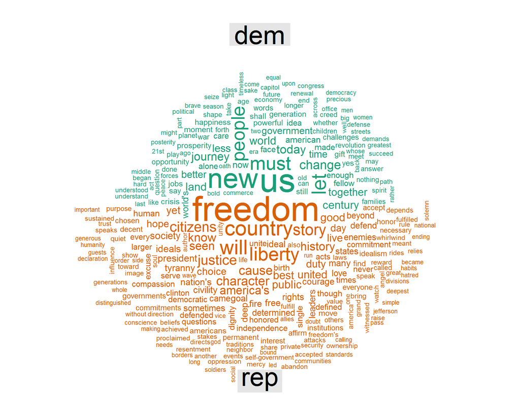

```r
wordcloud::comparison.cloud(t(as.matrix(partyDfm)))
```